# p8105_hw2_to2345

Tianna_Ouyang

2019/09/24

```r
# Load the packages that will be used in this assignment
knitr::opts_chunk$set(echo = TRUE)
library(psych)
library(tidyr)
library(tidyverse)
library(readxl)
library(dplyr)
library(knitr)
library(kableExtra)
```

## Problem 1

```r
# Read and clean the Mr. Trash Wheel sheet
trash_data =
  readxl::read_excel(
    "../data/Trash-Wheel-Collection-Totals-8-6-19.xlsx",
    sheet = 1,
    range = "A2:N406"
    ) %>%
  janitor::clean_names() %>%
  na.omit() %>%
  mutate(
    sports_balls = as.integer(round(sports_balls, 0))
  ) %>%
  view

# Read and clean precipitation data for 2017 and 2018
precipitation_2018 =
  readxl::read_excel(
  "../data/HealthyHarborWaterWheelTotals2018-7-28.xlsx",
  sheet = "2018 Precipitation",
  range = "A2:B14"
  ) %>%
  mutate(year = '2018') %>%
  view

precipitation_2017 =
  readxl::read_excel(
  "../data/HealthyHarborWaterWheelTotals2018-7-28.xlsx",
  sheet = "2017 Precipitation",
  range = "A2:B14"
  ) %>%
  mutate(year = '2017') %>%
  view

precipitation =
  bind_rows(precipitation_2017, precipitation_2018) %>%
  janitor::clean_names() %>%
  mutate(
    month = month.name[month]
  ) %>%
  view
```

- The cleaned Mr.Trash Wheel dataset has 14 variables, 344 records.
- The precipitation data for 2017 and 2018 dataset has 3 variables, 24 records.
- Some basic descriptive datas for the weight of trash in tons from Mr.Trash Wheel Dataset are:
  - Mean: 3.262936
  - Median: 3.265
  - Min: 0.96
  - Max: 5.62
  - Variance: 0.5582237
  - Skewness: 0.0087192
- For available data, the total precipitation in 2018 is 23.5;
- The median number of sports balls in a dumpster in 2017 is 8.

## Problem 2

```r
# import and clean the data in pols-month.csv
pols_month =
  read_csv("../data/fivethirtyeight_datasets/pols-month.csv") %>%
  janitor::clean_names() %>%
  separate(mon, into = c('year','month','day', sep = '-')) %>%
  mutate(
    month = month.name[as.integer(month)],
    year = as.integer(year),
    president = recode(prez_gop, '1' = 'gop', '0' = 'dem')) %>%
  select(-c('prez_dem','prez_gop','-','day')) %>%
  view
# import and  clean the data in snp.csv
snp =
  read_csv('../data/fivethirtyeight_datasets/snp.csv') %>%
  janitor::clean_names() %>%
  separate(date, into = c('month','day','year', sep = '/')) %>%
  mutate(
    month = month.name[as.integer(month)],
    year = as.integer(year)
    ) %>%
  select(year, month, close) %>%
  arrange(year, match(month, month.name)) %>%
  view
# define a function to capitalize the first character in a string (will eb s)
firstup <- function(x) {
  substr(x, 1, 1) <- toupper(substr(x, 1, 1))
  x}

# import and tidy the unemployment data so that it can be merged with the previous datasets
unemployment =
  read_csv('../data/fivethirtyeight_datasets/unemployment.csv') %>%
  janitor::clean_names() %>%
  pivot_longer(
    jan:dec,
    names_to = 'month',
    values_to = 'unemployment') %>%
  mutate(
    month = firstup(month),
    month = month.name[match(month, month.abb)]
  ) %>%
  view
```

*Join the datasets by merging snp into pols, and merging unemployment into the result.*

```r
# Join the dataset imported with common keys into new dataset
result = left_join(pols_month, snp, by = c('year' = 'year','month' = 'month'))
result = left_join(result, unemployment, by = c('year' = 'year', 'month' = 'month'))
```

*Write a short paragraph about these datasets. Explain briefly what each dataset contained, and describe the resulting dataset (e.g. give the dimension, range of years, and names of key variables).*

- The pols-month dataset has 9 variables, 822 records.
  - The variables in this dataset are year, month, gov_gop, sen_gop, rep_gop, gov_dem, sen_dem, rep_dem, president.
- The snp dataset has 3 variables, 787 records.
  - The variables in the dataset are year, month, close.
- The unemployment dataset has 3 variables, 816 records.
  - The variables in the dataset are year, month, unemployment
- The resulting dataset has 11 variables, 822 records.
  - The range of years in the resulting dataset is [1947, 2015]
  - The variables in the resulting dataset are: year, month, gov_gop, sen_gop, rep_gop, gov_dem, sen_dem, rep_dem, president, close, unemployment.

## Problem 3

*the names of a categorical predictor and the case structure of string variables changed over time; you’ll need to address this in your data cleaning.* *Also, some rows seem duplicated, and these will need to be removed.*

```r
# import the popular baby names file and perform corresponding data cleaning
baby_name =
  read_csv("../data/Popular_Baby_Names.csv", col_types = "icccii") %>%
  janitor::clean_names() %>%
  mutate(
    gender = str_to_lower(gender),
    ethnicity = str_to_lower(ethnicity),
    childs_first_name = str_to_lower(childs_first_name)
  ) %>%
  distinct() %>%
  view
```

*Produce a table showing the rank in popularity of the name “Olivia” as a female baby name over time; this should have rows for ethnicities and columns for year.*

```r
# make a new table based on the data subsetting from original dataframe with condition
olivia = subset(baby_name, childs_first_name == "olivia" & gender == "female")
olivia = select(olivia, year_of_birth, ethnicity, rank)
kable(olivia, caption = "The popularity of 'Olivia' in female baby over time") %>%
  kable_styling(bootstrap_options = c("striped", "hover", "condensed"), full_width = F)
```

The popularity of ‘Olivia’ in female baby over time

| year_of_birth | ethnicity | rank |
| --- | --- | --- |
| 2016 | asian and pacific islander | 1 |
| 2016 | black non hispanic | 8 |
| 2016 | hispanic | 13 |
| 2016 | white non hispanic | 1 |
| 2015 | asian and pacific islander | 1 |
| 2015 | black non hispanic | 4 |
| 2015 | hispanic | 16 |
| 2015 | white non hispanic | 1 |
| 2014 | asian and pacific islander | 1 |
| 2014 | black non hispanic | 8 |
| 2014 | hispanic | 16 |
| 2014 | white non hispanic | 1 |
| 2013 | asian and pacific islander | 3 |
| 2013 | black non hispanic | 6 |
| 2013 | hispanic | 22 |
| 2013 | white non hispanic | 1 |
| 2012 | asian and paci | 3 |
| 2012 | black non hisp | 8 |
| 2012 | hispanic | 22 |
| 2012 | white non hisp | 4 |
| 2011 | asian and pacific islander | 4 |
| 2011 | black non hispanic | 10 |
| 2011 | hispanic | 18 |
| 2011 | white non hispanic | 2 |

*for male, white non-hispanic children born in 2016, produce a scatter plot showing the number of children with a name (y axis) against the rank in popularity of that name (x axis)*

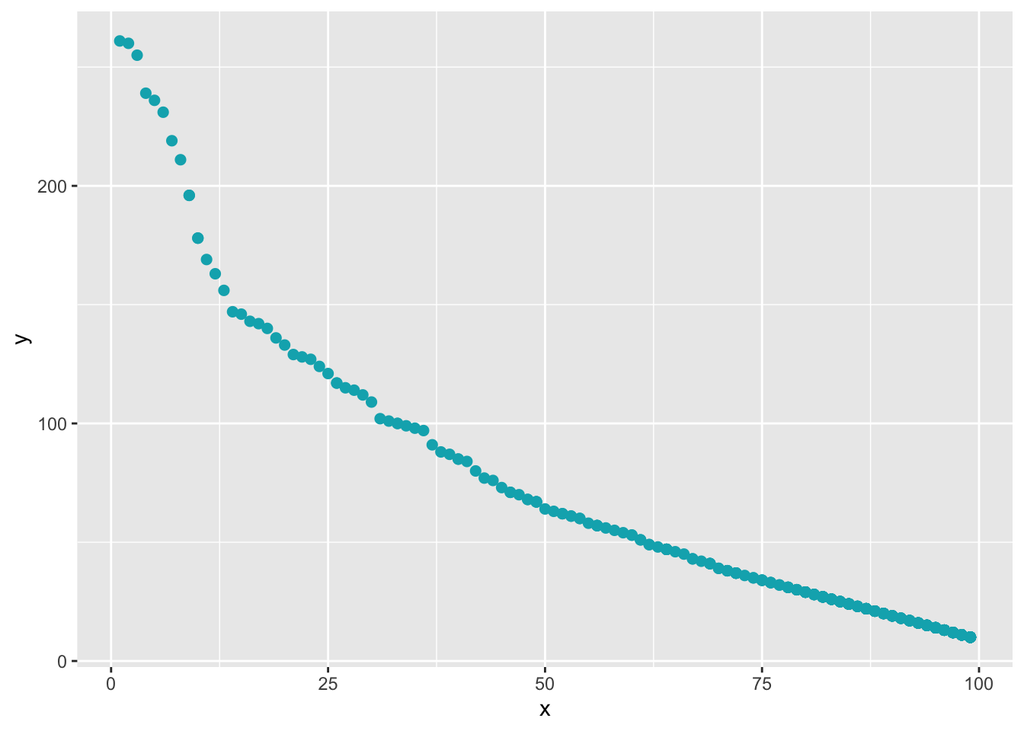

```r
# make a scatter plot describing the relationship between rank and the count of names
scatter_point = subset(baby_name, gender == "male" & ethnicity == "white non hispanic" & year_of_birth == 2016)
plot_df = tibble(
  x = pull(scatter_point, rank),
  y = pull(scatter_point, count)
)
ggplot(plot_df, aes(x = x, y = y))+ geom_point(color = "#00AFBB", size = 2)
```

- From the scatter plot we can see that there is a negative relationship between the number of childen with a name and the rank in popularity of that name, in other words, the higher the number of childer with a name, the rank in popularity of that name will be smaller for male, white non-hispanic children in 2016.